```python
import pandas as pd
import numpy as np
from sklearn.preprocessing import StandardScaler
import seaborn as sns
import matplotlib.pyplot as plt
from kmodes.kmodes import KModes
from kmodes.kprototypes import KPrototypes
from sklearn.cluster import KMeans
df = pd.read_csv('data/online.csv', na_filter=True)
```

# 1. Data Preparation for Clustering

**Can you identify data quality issues in this dataset such as unusual data types, missing values, etc?**

```python
nan_list = list()
for c_name in list(df):
    if(df[c_name].isnull().values.any()):
        nan_list.append(c_name)

print("\n Dropping columns with NaN values.")
df = df.dropna(subset=nan_list)
```

```
 Dropping columns with NaN values.
```

# 2. The first clustering model

**Build a clustering model to profile the customers based on the time they spend on the website.**

Building initial clustering based on; ProductRelated_Duration, Informational_Duration, Administrative_Duration.

```python
# Make dataset...
initial = df[['ProductRelated_Duration', 'Informational_Duration', 'Administrative_Duration']]
dataset = initial.as_matrix()
```

**What is the optimal number of clusters?**  
3 seems to be a pretty good number of clusters using the elbow method.

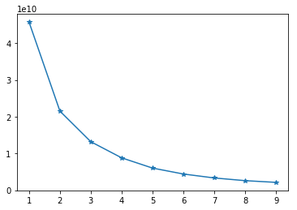

```python
clusters = []
inertia_vals = []

for k in range(1, 10):
    model = KMeans(n_clusters=k, random_state=1, n_jobs=10)
    model.fit(dataset)
    clusters.append(model)
    inertia_vals.append(model.inertia_)
plt.plot(range(1,10), inertia_vals, marker='*')
plt.show()
```

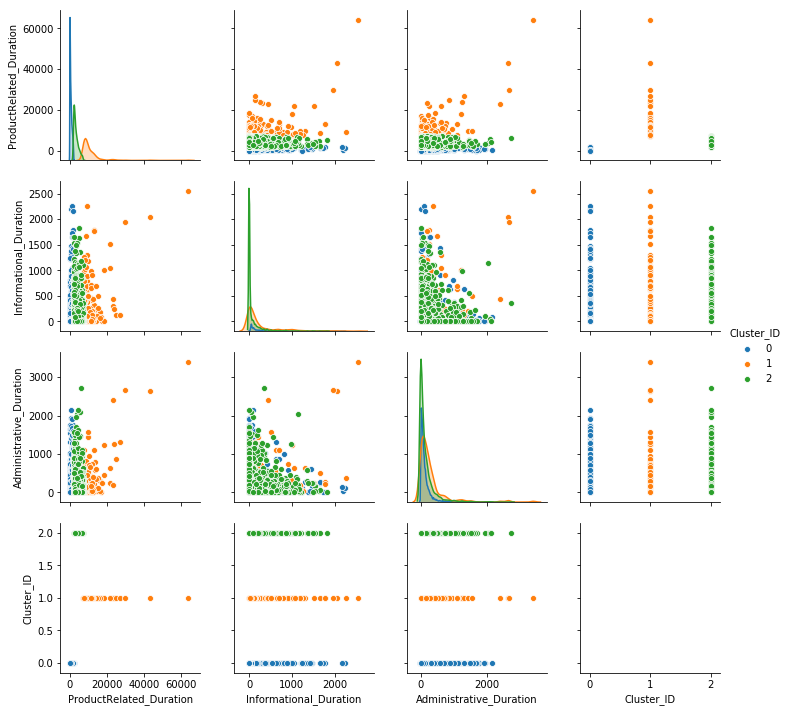

```python
model = KMeans(n_clusters=3, random_state=1)
model.fit(dataset)
y = model.predict(dataset)
initial['Cluster_ID'] = y
sns.pairplot(initial, hue='Cluster_ID')
plt.show()
```

**Explain the cluster results**  
Visitors seems to fit into three categories

## Applying scaling...

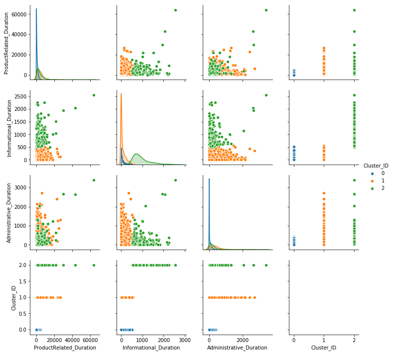

```python
# Make dataset and scale...
initial_scaled = df[['ProductRelated_Duration', 'Informational_Duration', 'Administrative_Duration']]
dataset_scaled = initial_scaled.as_matrix()
scaler = StandardScaler()
dataset_scaled = scaler.fit_transform(dataset_scaled)

model = KMeans(n_clusters=3, random_state=1)
model.fit(dataset_scaled)
y = model.predict(dataset_scaled)
initial_scaled['Cluster_ID'] = y
sns.pairplot(initial_scaled, hue='Cluster_ID')
plt.show()
```

**What is the effect of using the standardization method on the model above? Does the variable normalization process enable a better clustering solution?**  
The vistors are now divided into three new categories, which might be of better use to the company as they could focus on the blue category to increase engagement:

- Spend most time on information pages (green)
- Spend very little total time on the website (blue)
- Spend a good amount of type on adminstrative and product pages (orange)

# Refining the clustering model

**Add more information such as where the users come from and when they access the website, to the clustering analysis that you have conducted in the previous task.**

We have decided to group all durations together to have the combined duration of time on the webpage. Also, visitortype, month, revenye, traffic type and region is taken into consideration.

```python
df['Duration'] = df['ProductRelated_Duration'] + df['Informational_Duration'] + df['Administrative_Duration']
df['VisitorType'] = df['VisitorType'].map({'Returning_Visitor':1, 'New_Visitor': 2,'Other': 3})
df['Month'] = df['Month'].map({'Jan':1, 'Feb': 2,'Mar': 3, 'Aug': 4, 'May': 5, 'June': 6, 'Jul': 7, 'Aug': 8, 'Sep': 9, 'Oct': 10, 'Nov': 11, 'Dec': 12})
refined = df[['Duration', 'VisitorType', 'Revenue', 'TrafficType', 'Region', 'Month']]
refined_dataset = refined.as_matrix()
```

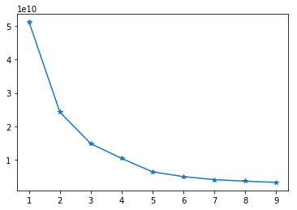

```python
clusters = []
inertia_vals = []

for k in range(1, 10):
    model = KPrototypes(n_clusters=k, init='Huang')
    model.fit_predict(refined_dataset, categorical=[1,2,3,4,5])
    clusters.append(model)
    inertia_vals.append(model.cost_)
plt.plot(range(1,10), inertia_vals, marker='*')
plt.show()
```

**What is the optimal number of clusters?** Seems to still be 3.

```python
rmodel=KPrototypes(n_clusters=3, init='Huang')
y_refined=rmodel.fit_predict(refined_dataset, categorical=[1,2,3,4,5])
refined['Cluster_ID'] = y_refined
```

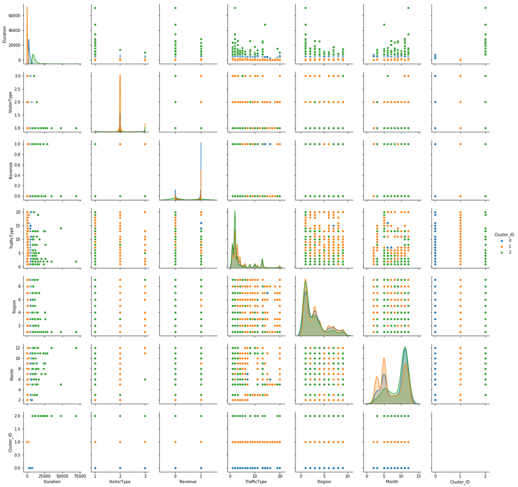

```python
sns.pairplot(refined, hue='Cluster_ID')
plt.show()
```

**Whether this model has different variable importance than the previous model (Task 2.1)?** Yes, as all the durations are now grouped together. The most important variable here is duration (only non-categorial variable).

**What is the effect of using the standardization method on the model above? Does the variable normalization process enable a better clustering solution?** Has no effect on this graph as there is only one non-categorial variable.

**Can you highlight the differences between the two clustering solutions (Tasks 2.1 & 3.1) focusing on cluster interpretation? In other words, explain what is the effect of adding other variables in the clustering analysis?**  
In general, adding more variables makes the clusters harder to interprete. Clustering is more interesting with non-categorial data, and most of this is categorial.